# Data Science Capstone Milestone Report

Danna Ashley J. Mayo

August 15, 2019 - Thursday

## Executive Summary

The John Hopkins University Data Science Program provided a dataset for us to perform a thorough exploratory data analysis, understanding of the distribution of words, and relationship between words in the corpora which will be seen in this Milestone Report. Furthermore, we will understand the different frequencies of words or word pairs by building figures and tables to understand variation int he frequencies of words or word pairs in the data. Lastly, it will only explain major features of the data identified and briefly summarize the plans for creating the prediction algorithm and the shiny application.

*It is assumed that the dataset has been downloaded, unzipped, and saved into the working directory from this link: https://d396qusza40orc.cloudfront.net/dsscapstone/dataset/Coursera-SwiftKey.zip*

### Data Preparation

```r
# Load the necessary libraries first (install packages if not yet done)
library(dplyr)
library(plyr)
library(stringi)
library(quanteda)
library(tm)
library(ggplot2)
library(NLP)
library(data.table)
library(wordcloud)

# Reading the datasets
en_blog <- readLines(con = "final/en_US/en_US.blogs.txt", encoding= "UTF-8", skipNul = T)
en_news <- readLines(con = "final/en_US/en_US.news.txt", encoding= "UTF-8", skipNul = T)
en_twitter <- readLines(con = "final/en_US/en_US.twitter.txt", encoding= "UTF-8", skipNul = T)
```

### Data Exploration

In this section, we will try to look at some of the high level aggregations of the text files.

```r
# Sampling the data given the large dataset and performing different aggregations for summary
samp_blog <- sample(length(en_blog), length(en_blog) * 0.1)
samp_news <- sample(length(en_news), length(en_news) * 0.1)
samp_twitter <- sample(length(en_twitter), length(en_twitter) * 0.1)
s_blog <- en_blog[samp_blog]
s_news<- en_news[samp_news]
s_twitter <- en_twitter[samp_twitter]
nchar_en_blog <- sum(nchar(samp_blog))
nchar_en_news <- sum(nchar(samp_news))
nchar_en_twitter <- sum(nchar(samp_twitter))
m_blog <- stri_count_words(s_blog)
m_news <- stri_count_words(s_news)
m_twitter <- stri_count_words(s_twitter)
num_blog <-stri_stats_latex(s_blog)[4]
num_news <-stri_stats_latex(s_news)[4]
num_twitter <-stri_stats_latex(s_twitter)[4]
```

```r
# Summary from the sampled data prepared above
data.frame("Data Source" = c("Blog", "News", "Twitter"),
           "Lines" = c(length(s_blog),length(s_news), length(s_twitter)),
           "Words" = c(sum(num_blog), sum(num_news), sum(num_twitter)),
           "Characters" = c(nchar_en_blog,nchar_en_news, nchar_en_twitter),
           "Average number of words" = c(mean(m_blog), mean(m_news), mean(m_twitter)))
```

```
##   Data.Source  Lines   Words Characters Average.number.of.words
## 1        Blog  89928 3727312     528509                41.41458
## 2        News   7725  263280      37575                34.52207
## 3     Twitter 236014 3044848    1540933                12.74889
```

### Data Cleaning/Preprocessing

Converting to corpus objects.

```r
# Combine the text documents and convert to corpus objects
master_vector <- c(s_blog, s_news, s_twitter)
corp <- corpus(master_vector)
```

We now remove the unnecessary items in the text files not needed in predicting.

```r
# Removing the punctuations and/or numbers
cleaning <- tokens(
    x = tolower(corp),
    remove_punct = TRUE,
    remove_twitter = TRUE,
    remove_numbers = TRUE,
    remove_hyphens = TRUE,
    remove_symbols = TRUE,
    remove_url = TRUE
)
```

```r
# After cleaning, we now stem it
stem_words <- tokens_wordstem(cleaning, language = "english")
```

### Tokenization and N-Gram Modeling

Let’s create N-grams and Document Frequency Matrices from the corpus.

```r
bi_gram <- tokens_ngrams(stem_words, n = 2)
tri_gram <- tokens_ngrams(stem_words, n = 3)

uni_DFM <- dfm(stem_words)
bi_DFM <- dfm(bi_gram)
tri_DFM <- dfm(tri_gram)

# Let us trim the N-Grams for faster calculations
uni_DFM <- dfm_trim(uni_DFM, 3)
bi_DFM <- dfm_trim(bi_DFM, 3)
tri_DFM <- dfm_trim(tri_DFM, 3)
```

Now let’s group the word tokens to find the count in the corpus.

```r
# Create named vectors with counts of words
sum_uni <- colSums(uni_DFM)
sum_bi <- colSums(bi_DFM)
sum_tri <- colSums(tri_DFM)

# Create data tables with individual words as columns
uni_words <- data.table(One_Word = names(sum_uni), Frequency = sum_uni)

bi_words <- data.table(
        One_Word = sapply(strsplit(names(sum_bi), "_", fixed = TRUE), '[[', 1),
        Two_Words = sapply(strsplit(names(sum_bi), "_", fixed = TRUE), '[[', 2),
        Frequency = sum_bi)

tri_words <- data.table(
        One_Word = sapply(strsplit(names(sum_tri), "_", fixed = TRUE), '[[', 1),
        Two_Words = sapply(strsplit(names(sum_tri), "_", fixed = TRUE), '[[', 2),
        Three_Words = sapply(strsplit(names(sum_tri), "_", fixed = TRUE), '[[', 3),
        Frequency = sum_tri)
```

#### Unigram Analysis

**Unigram Frequency (Top 15)**

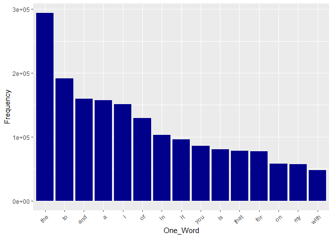

```r
graph.data <- uni_words[order(uni_words$Frequency, decreasing = T), ]
graph.data <- graph.data[1:15, ]
graph.data$One_Word <- factor(graph.data$One_Word, levels = graph.data$One_Word)

ggplot(data=graph.data, aes(x=One_Word, y=Frequency)) + geom_bar(stat="identity", fill = "darkblue") +
    theme(axis.text.x = element_text(angle = 40, hjust = 1))
```

**Top 50 Unigrams Word Cloud**

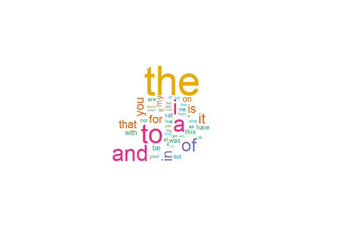

```r
set.seed(28)
wordcloud(names(sum_uni), sum_uni, max.words=50, scale=c(5, .1), colors=brewer.pal(6, "Dark2"))
```

#### Bigram Analysis

**Bigram Frequency (Top 15)**

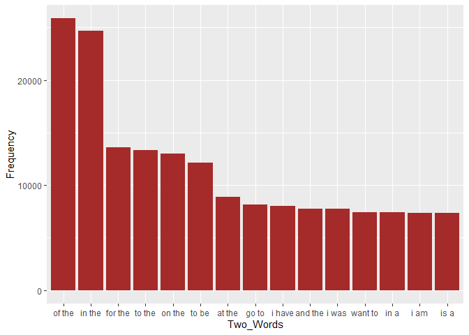

```r
graph.data <- bi_words[order(bi_words$Frequency, decreasing = T), ]
graph.data <- graph.data[1:15, ]
graph.data$Two_Words <- paste(graph.data$One_Word, graph.data$Two_Words)
graph.data$Two_Words <- factor(graph.data$Two_Words, levels = graph.data$Two_Words)

ggplot(data=graph.data, aes(x=Two_Words, y=Frequency)) + geom_bar(stat="identity", fill = "brown")
```

**Top 50 Bigrams Word Cloud**

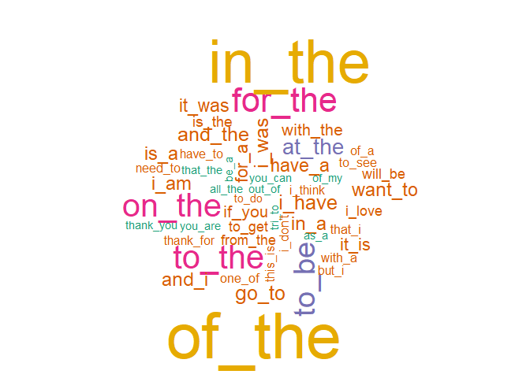

```r
set.seed(28)
wordcloud(names(sum_bi), sum_bi, max.words=50, scale=c(5, .1), colors=brewer.pal(6, "Dark2"))
```

#### Trigram Analysis

**Trigram Frequency (Top 15)**

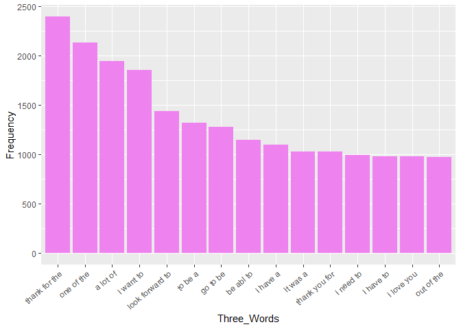

```r
graph.data <- tri_words[order(tri_words$Frequency, decreasing = T), ]
graph.data <- graph.data[1:15, ]
graph.data$Three_Words <- paste(graph.data$One_Word, graph.data$Two_Words, graph.data$Three_Words)
graph.data$Three_Words <- factor(graph.data$Three_Words, levels = graph.data$Three_Words)

ggplot(data=graph.data, aes(x=Three_Words, y=Frequency)) + geom_bar(stat="identity", fill = "violet") +
    theme(axis.text.x = element_text(angle = 40, hjust = 1))
```

**Top 50 Trigrams Word Cloud**

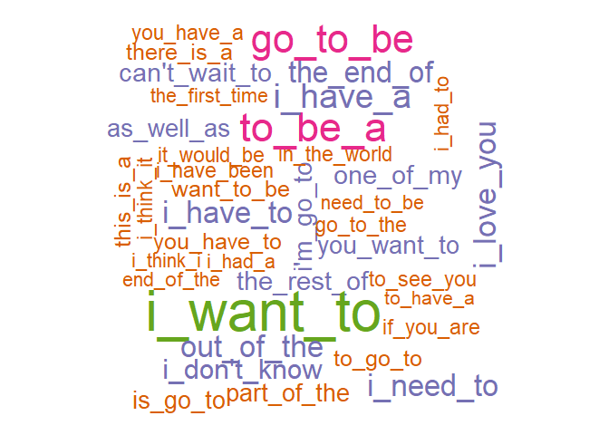

```r
library(wordcloud)
set.seed(28)
wordcloud(names(sum_tri), sum_tri, max.words=50, scale=c(5, .1), colors=brewer.pal(6, "Dark2"))
```

### Next Steps: Prediction Algorithm and Shiny Application

Now that we’re done with our exploratory data analysis, the next step is to create a predictive model for word prediction and deploy it into a shiny application so external users are able to benefit from it.

**How to make it?**

- Preprocessing executed should be considered
- Using the n-gram model with frequency created above.
- Feasibly, we will be using the trigram model to predict the next word. If no match will be found, the algorithm would most likely back off to the bigram model, them to the unigram model if necessary.

**How will it look like?**

The user interface of the shiny application is expected to be as simple and user-friendly as possible for the ease of the users in navigating. Lastly, hopefully that the application would be able to accurately and quickly help the users for word prediction.